# R Notebook

## Introduccion

A continuación se realiza un análisis exploratorio de los datos suministrados correspondientes a aleación Zr2.5Nb, la cuales fueron hidruradas para finalmente obtener muestras conteniendo concentraciones de H de 2ppm, 23ppm, 42ppm, 79ppm, 99ppm. `Que exactitud tiene esta medida?`. Los datos corresponden a 140 espectros para cada muestra, y están divididos en dos grupos, el primero de 40 y el segundo de 100, tomados en días diferentes. `¿existe información importante que varia de día a día?`

## Lectura de Datos

```r
library(tidyverse)
source('./funciones utiles.R')
source('./Funciones_Prepocesado.R')

data.path<- list(dia1 = "./Data/Calibracion Zr2.5Nb - 4.53 J- 2.92us/",
                 dia2 = "./Data/new data/")
carpetas <- list('ARG-2','ARG-4','ARG-3','ARG-5','ARG-6')
data <- vector(mode = 'list', length = 2)

data[[1]] <- lapply(carpetas, function(x){df_func(data.path[[1]], x, 40)})
data[[2]] <- lapply(carpetas, function(x){df_func(data.path[[2]], x, 100)})

wavelen <- read_tsv(file = paste(data.path[[1]], 'ARG-2/a1.ols', sep = '' ),
                    skip = 6) %>%
                select(Wavelength) %>%
                rowid_to_column()
```

### Espectro promedio para la muestra 99ppm, datos dia 1.

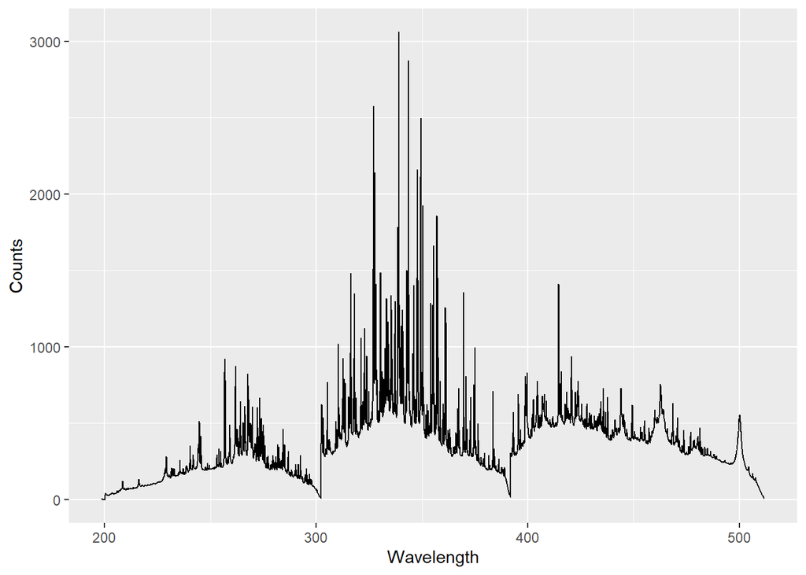

## Picos de H

No vale la pena graficar los 5 espectros promedio en la misma gráfica, así que se exploran por separado los picos de hidrógeno :

#### Pico 383.65nm

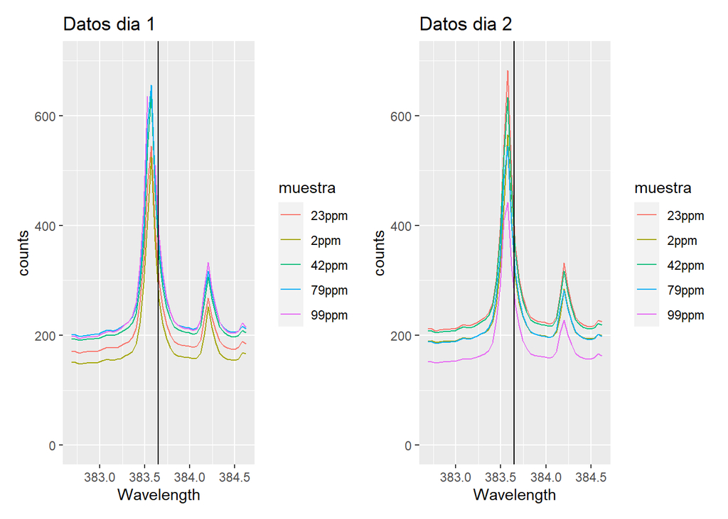

#### Pico 389nm

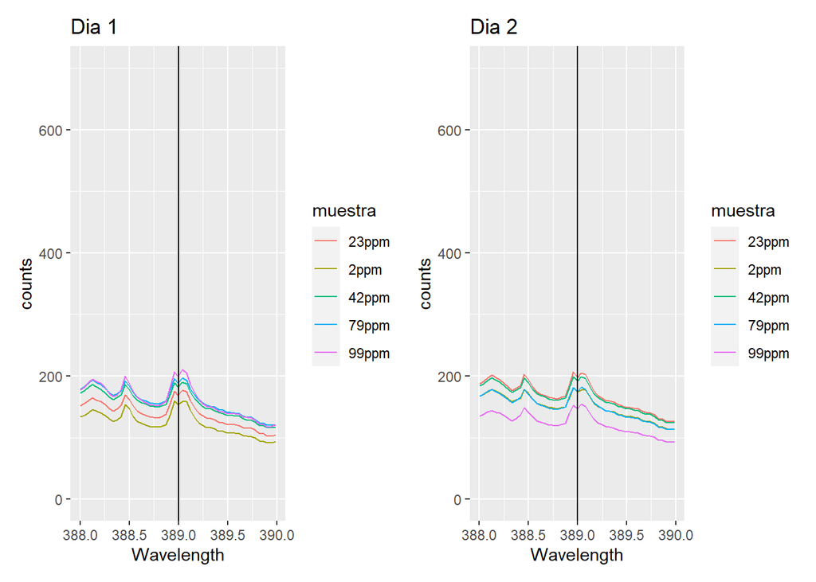

#### Pico 397.1nm

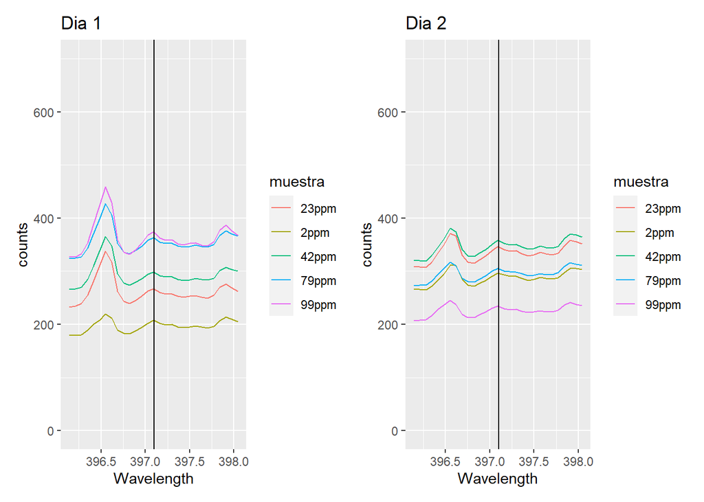

#### Pico 410.3nm

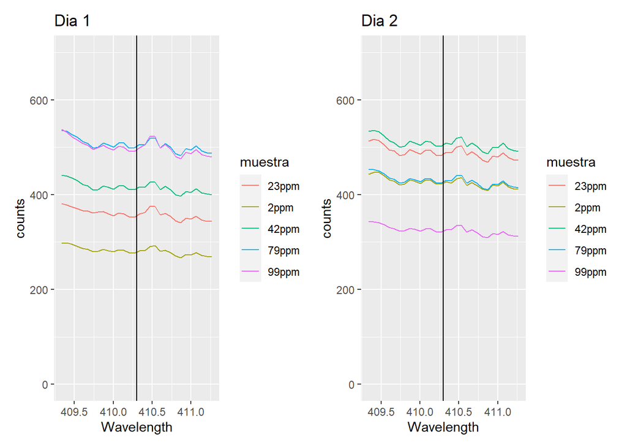

#### Pico 434.15nm

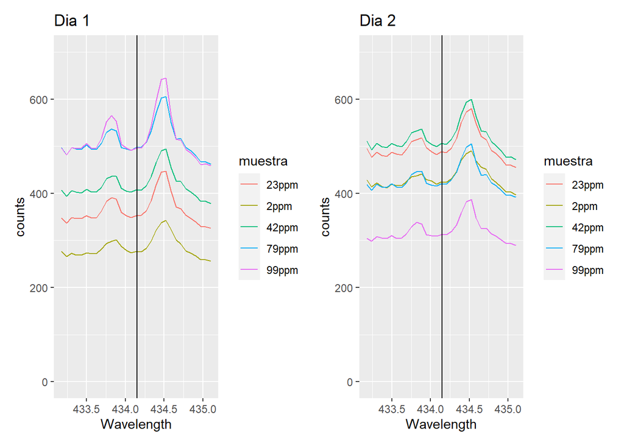

#### Pico 486.25nm

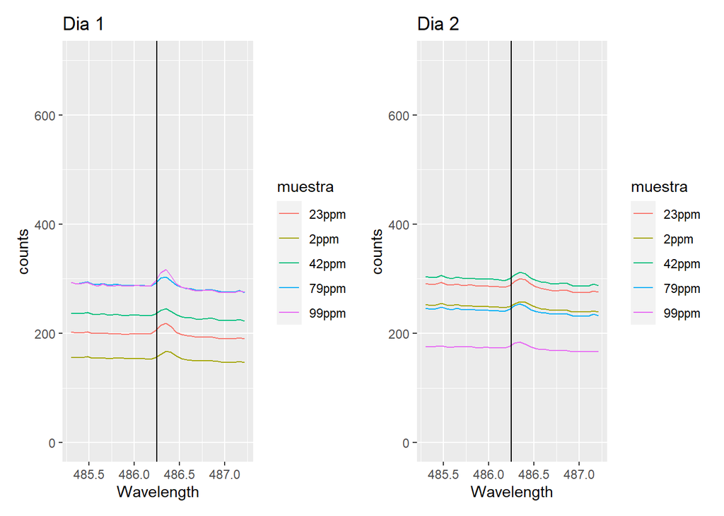

Se observa un comportamiento extraño en las observaciones; la muestra de 99ppm es la mas alta el primer día, pero, pasa a ser la mas baja en las mediciones del día 2. ¿Por que?

Aparentemente los ‘mejores picos de H’, los que deberían apreciarse en el detector numero 3, no se manifiestan claramente. ¿Para una primera aproximación convendría trabajar solo con datos del detector 2 que es en donde se ve la primera linea de H perfectamente diferenciada?

## Inspección de los picos de H normalizando los datos

En este apartado se repite el mismo análisis exploratorio con la diferencia de que se normalizan los espectros por suma total y se sustrae la linea base.

#### Comparacion de espectro normalizado antes y despues de sustraer linea base

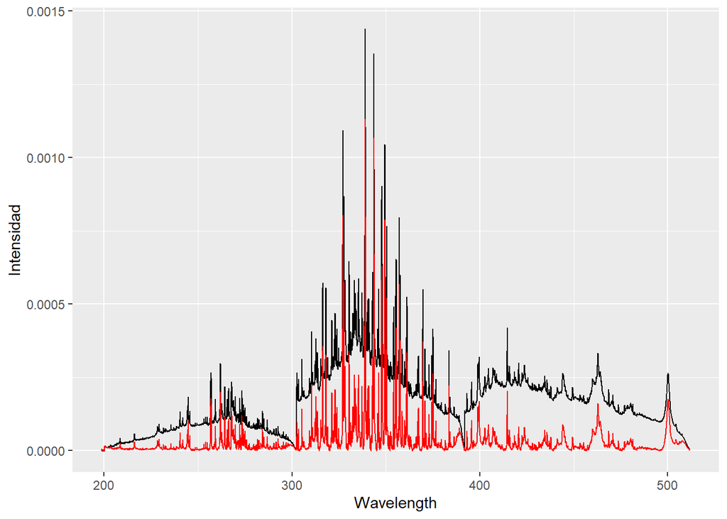

```r
g <- FUN.plot.comp(wavelen, old.spec[[1]][[1]], new.spec[[1]][[1]], n = 1)
g
```

En la siguiente imagen se observa la posición de las longitudes de onda correspondientes a los picos de H (lineas azules). La rutina de remoción de la linea base no funciona bien para los extremos de los detectores, en la linea numero 2 (de izquierda a derecha) se observa que el supuesto pico de H queda perturbado por este motivo. `CORREGIR ESTO`

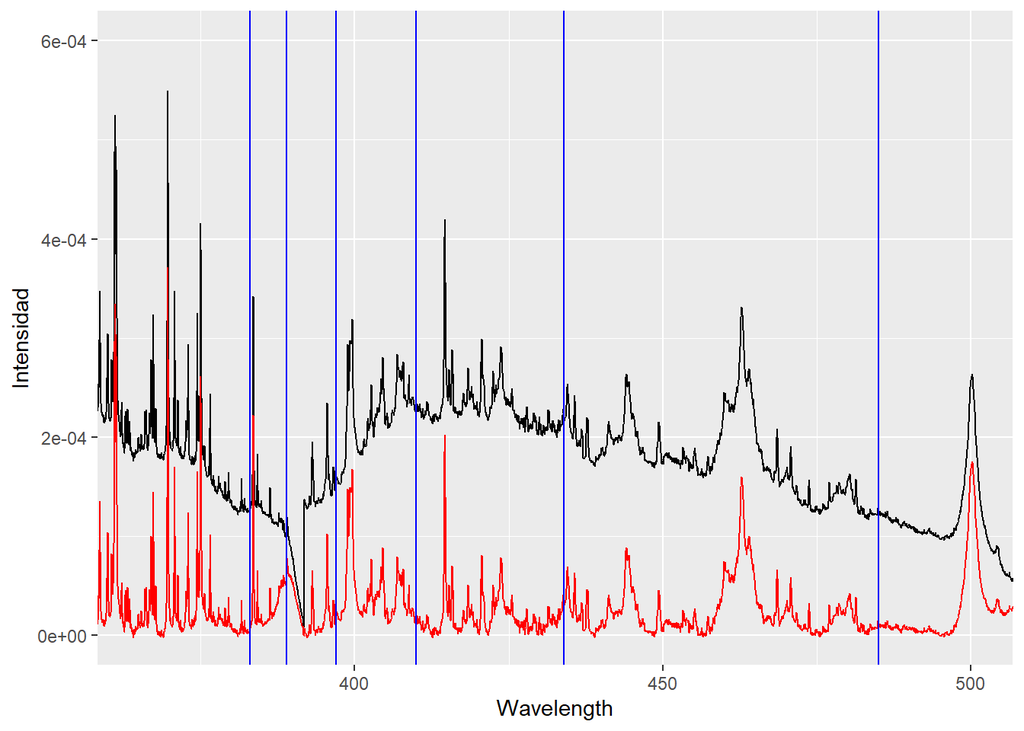

#### Pico 383.65nm

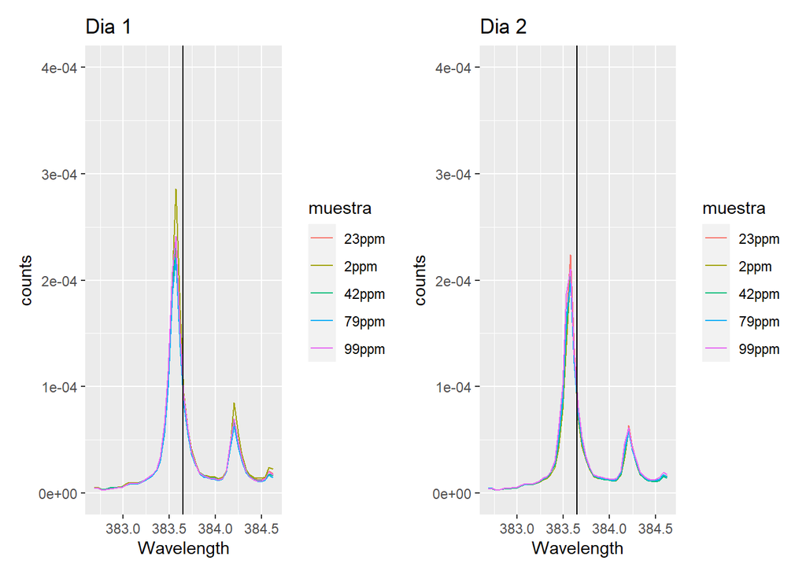

#### Pico 389nm

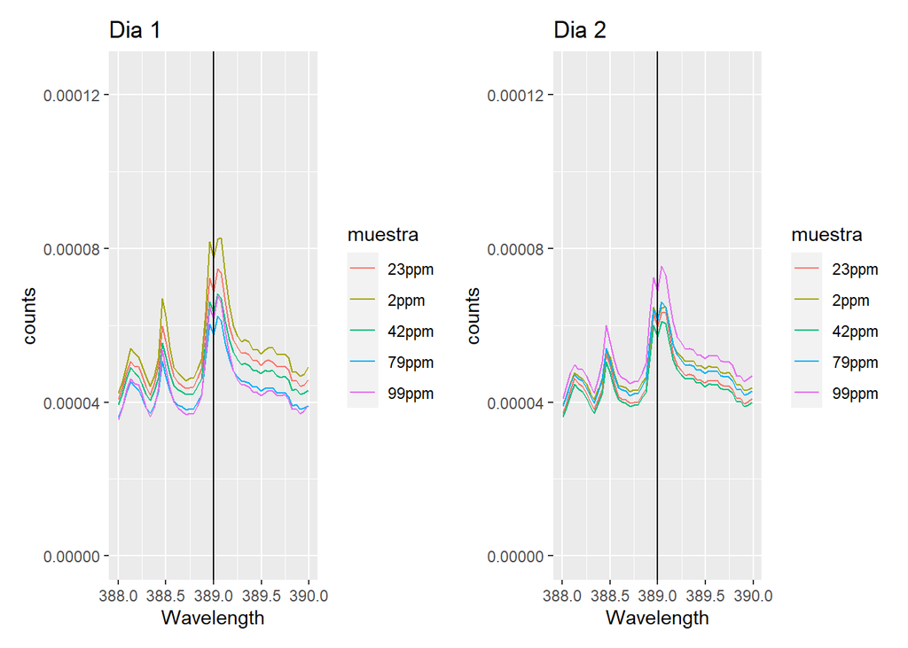

#### Pico 397.1nm

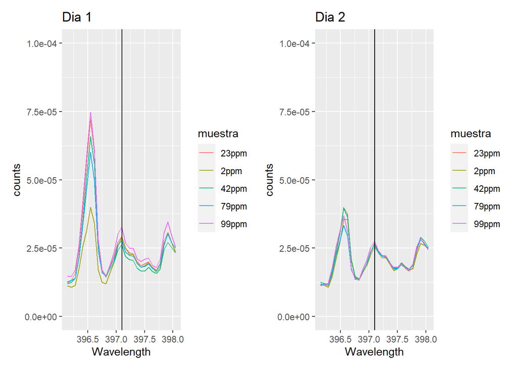

#### Pico 410.3nm

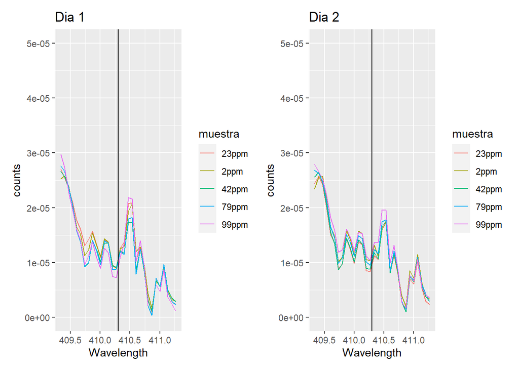

#### PIco 434.15nm

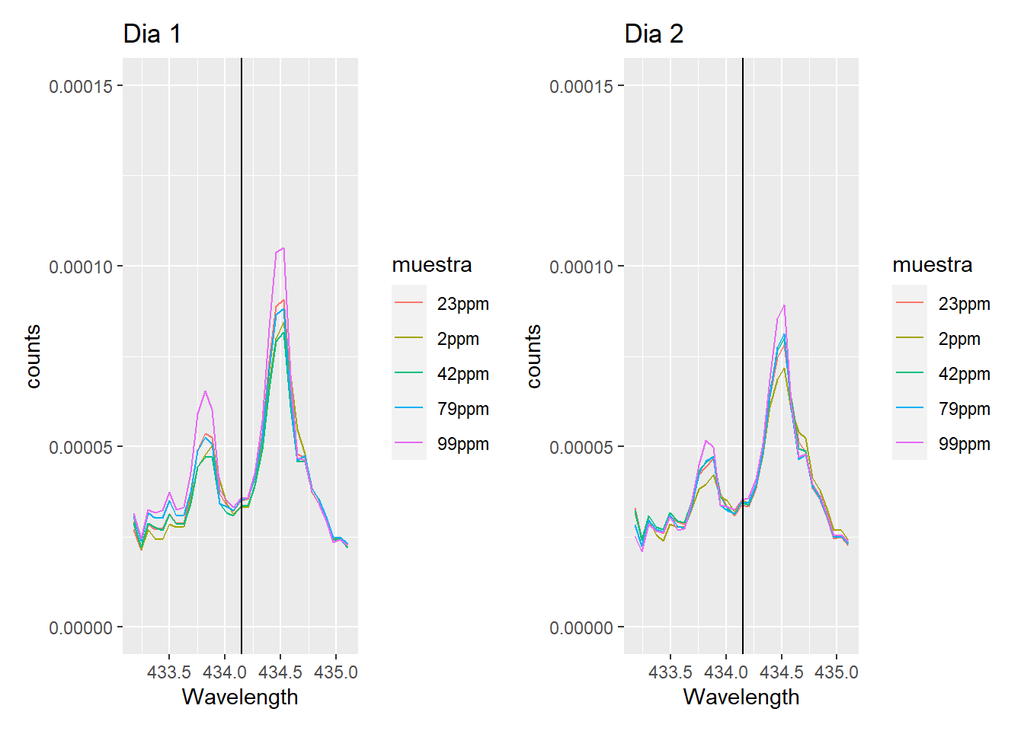

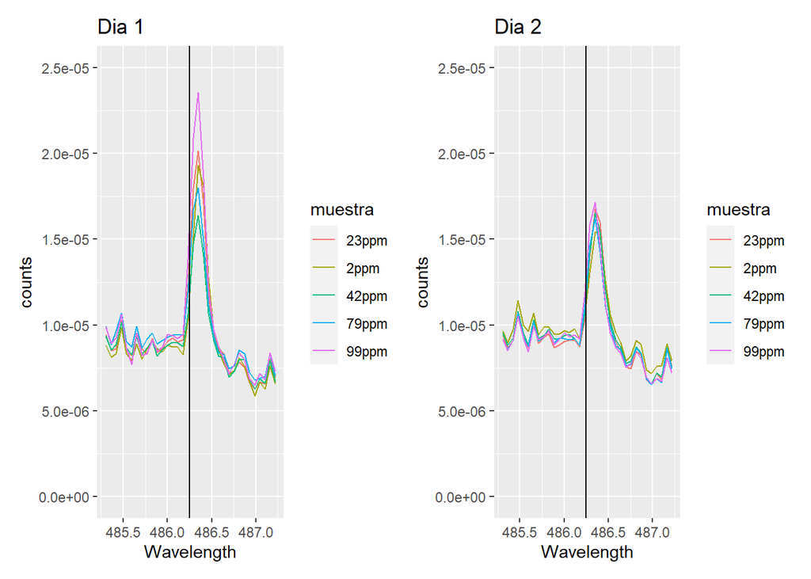